# p8105_hw3_yc4804

Yilin Cai

2025-10-11

## Problem 1

```r
library(p8105.datasets)
library(tidyverse)
data("instacart")
instacart
```

```
## # A tibble: 1,384,617 × 15
##    order_id product_id add_to_cart_order reordered user_id eval_set order_number
##       <int>      <int>             <int>     <int>   <int> <chr>           <int>
##  1        1      49302                 1         1  112108 train               4
##  2        1      11109                 2         1  112108 train               4
##  3        1      10246                 3         0  112108 train               4
##  4        1      49683                 4         0  112108 train               4
##  5        1      43633                 5         1  112108 train               4
##  6        1      13176                 6         0  112108 train               4
##  7        1      47209                 7         0  112108 train               4
##  8        1      22035                 8         1  112108 train               4
##  9       36      39612                 1         0   79431 train              23
## 10       36      19660                 2         1   79431 train              23
## # ℹ 1,384,607 more rows
## # ℹ 8 more variables: order_dow <int>, order_hour_of_day <int>,
## #   days_since_prior_order <int>, product_name <chr>, aisle_id <int>,
## #   department_id <int>, aisle <chr>, department <chr>
```

Dataset Description

The instacart dataset provides detailed information on grocery orders placed through the Instacart app. It contains 1,384,617 observations from 131,209 unique users, where each row represents a single product from a user’s order. Each user contributes exactly one order in this version of the dataset. There are 15 variables describing product details, order timing, and categorical classifications such as aisle and department. Key variables include: order_id: unique order identifier product_id: unique product identifier user_id: customer identifier product_name: name of the product aisle / department: product location categories order_dow: day of the week order placed (0 = Sunday, 6 = Saturday) order_hour_of_day: hour (0–23) when order was placed

```r
#Question 1: number of aisles and most ordered from
aisle_summary = instacart %>%
  count(aisle, sort = TRUE)

n_aisles = nrow(aisle_summary)
top_aisles = head(aisle_summary, 5)

n_aisles
```

```
## [1] 134
```

```r
top_aisles
```

```
## # A tibble: 5 × 2
##   aisle                           n
##   <chr>                       <int>
## 1 fresh vegetables           150609
## 2 fresh fruits               150473
## 3 packaged vegetables fruits  78493
## 4 yogurt                      55240
## 5 packaged cheese             41699
```

There are 134 aisles in total. The most ordered aisles include fresh vegetables, fresh fruits, packaged vegetables fruits, yogurt, and packaged cheese.

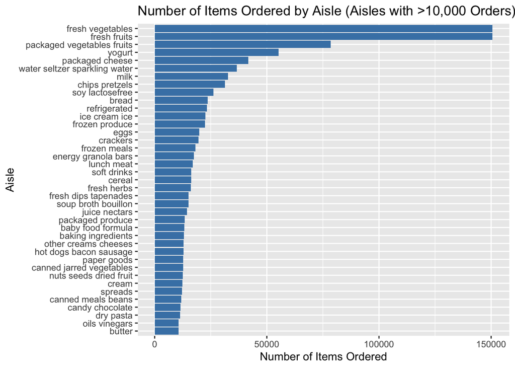

```r
#Question2: Plot — Number of Items Ordered per Aisle (Aisles > 10,000 Orders)
aisle_summary %>%
  filter(n > 10000) %>%
  mutate(aisle = fct_reorder(aisle, n)) %>%
  ggplot(aes(x = aisle, y = n)) +
  geom_col(fill = "steelblue") +
  coord_flip() +
  labs(
    title = "Number of Items Ordered by Aisle (Aisles with >10,000 Orders)",
    x = "Aisle",
    y = "Number of Items Ordered"
  )
```

```r
#The most popular items in selected aisles
popular_items = instacart %>%
  filter(aisle %in% c("baking ingredients", "dog food care", "packaged vegetables fruits")) %>%
  group_by(aisle, product_name) %>%
  summarize(order_count = n()) %>%
  arrange(aisle, desc(order_count)) %>%
  slice_head(n = 3)
knitr::kable(popular_items, caption = "Top 3 Most Popular Items in Selected Aisles")
```

Top 3 Most Popular Items in Selected Aisles

| aisle | product_name | order_count |
| --- | --- | --- |
| baking ingredients | Light Brown Sugar | 499 |
| baking ingredients | Pure Baking Soda | 387 |
| baking ingredients | Cane Sugar | 336 |
| dog food care | Snack Sticks Chicken & Rice Recipe Dog Treats | 30 |
| dog food care | Organix Chicken & Brown Rice Recipe | 28 |
| dog food care | Small Dog Biscuits | 26 |
| packaged vegetables fruits | Organic Baby Spinach | 9784 |
| packaged vegetables fruits | Organic Raspberries | 5546 |
| packaged vegetables fruits | Organic Blueberries | 4966 |

```r
#Question 4: Mean Hour of the Day Pink Lady Apples and Coffee Ice Cream are Ordered (by Day of Week)

mean_hour = instacart %>%
  filter(product_name %in% c("Pink Lady Apples", "Coffee Ice Cream")) %>%
  group_by(product_name, order_dow) %>%
  summarize(mean_hour = mean(order_hour_of_day)) %>%
  pivot_wider(
    names_from = order_dow,
    values_from = mean_hour
  )
colnames(mean_hour) = c("Product", "Sun", "Mon", "Tue", "Wed", "Thu", "Fri", "Sat")

knitr::kable(mean_hour, digits = 2, caption = "Mean Hour of Purchase by Day of Week")
```

Mean Hour of Purchase by Day of Week

| Product | Sun | Mon | Tue | Wed | Thu | Fri | Sat |
| --- | --- | --- | --- | --- | --- | --- | --- |
| Coffee Ice Cream | 13.77 | 14.32 | 15.38 | 15.32 | 15.22 | 12.26 | 13.83 |
| Pink Lady Apples | 13.44 | 11.36 | 11.70 | 14.25 | 11.55 | 12.78 | 11.94 |

## Problem 2

```r
library(tidyverse)
library(lubridate)
library(patchwork)
library(knitr)

# paths
zori_path <- "/Users/caiyilin/Desktop/p8105_hw3_yc4804/zillow_data/Zip_zori_uc_sfrcondomfr_sm_month_NYC.csv"
map_path  <- "/Users/caiyilin/Desktop/p8105_hw3_yc4804/zillow_data/Zip Codes.csv"

zori_raw <- readr::read_csv(zori_path, show_col_types = FALSE, name_repair = "minimal")
zip_map  <- readr::read_csv(map_path,  show_col_types = FALSE)

# columns in your files
zip_col_zillow <- "RegionName"   # ZIP in Zillow file
zip_col_map    <- "ZipCode"      # ZIP in mapping file
boro_col_map   <- "County"       # USE ORIGINAL COUNTY — NO RECODING

# monthly columns like "YYYY-MM" or "YYYY-MM-DD"
date_cols <- names(zori_raw)[grepl("^\\d{4}-\\d{2}(-\\d{2})?$", names(zori_raw))]

# long format + parse date
zori_long <- zori_raw |>
  pivot_longer(all_of(date_cols), names_to = "month_header", values_to = "zori") |>
  mutate(
    date = ymd(month_header, quiet = TRUE),
    date = if_else(is.na(date), ym(month_header, quiet = TRUE), date),
    zip  = str_pad(.data[[zip_col_zillow]] |> as.character(), 5, pad = "0")
  ) |>
  select(zip, date, zori) |>
  filter(!is.na(date)) |>
  filter(date >= ymd("2015-01-01"), date <= ymd("2024-08-31")) |>
  mutate(year = year(date))

# attach ORIGINAL county labels; keep them in a column named "borough"
zip_map_small <- zip_map |>
  transmute(
    zip     = str_pad(.data[[zip_col_map]] |> as.character(), 5, pad = "0"),
    borough = .data[[boro_col_map]] |> as.character()     # <- original County values (e.g., Kings)
  )

zori_long <- zori_long |>
  left_join(zip_map_small, by = "zip") |>
  mutate(
    # optional: order by county names rather than borough names
    borough = factor(borough, levels = c("New York","Kings","Queens","Bronx","Richmond"))
  ) |>
  select(zip, date, zori, year, borough)
view(zori_long)
```

```r
#Q1: Coverage counts across Jan 2015–Aug 2024 (116 months)
coverage <- zori_long %>%
  mutate(has_obs = !is.na(zori)) %>%
  group_by(zip) %>%
  summarize(n_months = sum(has_obs), .groups = "drop")

n_full_116 <- sum(coverage$n_months == 116, na.rm = TRUE)
n_lt_10    <- sum(coverage$n_months < 10,  na.rm = TRUE)

cat("ZIPs observed 116 times:", n_full_116, "\n")
```

```
## ZIPs observed 116 times: 47
```

```r
cat("ZIPs observed < 10 times:", n_lt_10, "\n")
```

```
## ZIPs observed < 10 times: 26
```

```r
#Q2) Reader-friendly table: average rental price by county*year
library(knitr)

avg_boro_year <- zori_long |>
  filter(!is.na(zori), !is.na(borough)) |>
  group_by(borough, year) |>
  summarise(mean_zori = round(mean(zori, na.rm = TRUE), 0), .groups = "drop") |>
  mutate(borough = factor(borough, levels = c("New York","Kings","Queens","Bronx","Richmond"))) |>
  arrange(borough, year) |>
  tidyr::pivot_wider(names_from = year, values_from = mean_zori)

kable(avg_boro_year, caption = "Average ZORI ($) by County and Year", align = "c")
```

Average ZORI ($) by County and Year

| borough | 2015 | 2016 | 2017 | 2018 | 2019 | 2020 | 2021 | 2022 | 2023 | 2024 |
| --- | --- | --- | --- | --- | --- | --- | --- | --- | --- | --- |
| New York | 3006 | 3015 | 3109 | 3160 | 3285 | 3091 | 3124 | 3753 | 3908 | 4053 |
| Kings | 2493 | 2520 | 2546 | 2547 | 2631 | 2555 | 2550 | 2868 | 3015 | 3126 |
| Queens | 2215 | 2272 | 2263 | 2292 | 2388 | 2316 | 2211 | 2406 | 2562 | 2694 |
| Bronx | 1760 | 1520 | 1544 | 1639 | 1706 | 1811 | 1858 | 2054 | 2285 | 2497 |
| Richmond | NA | NA | NA | NA | NA | 1978 | 2045 | 2147 | 2333 | 2536 |

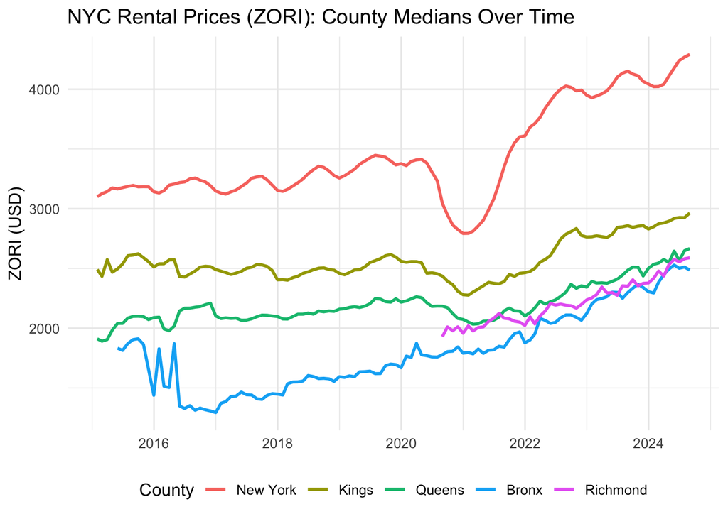

```r
#Q3) Plot: NYC rental prices over time (facilitates county comparisons)
library(ggplot2)

# Use monthly county medians for clarity with many ZIPs
boro_month_median <- zori_long |>
  filter(!is.na(zori), !is.na(borough)) |>
  group_by(borough, date) |>
  summarise(median_zori = median(zori, na.rm = TRUE), .groups = "drop") |>
  mutate(borough = factor(borough, levels = c("New York","Kings","Queens","Bronx","Richmond")))

p1 <- ggplot(boro_month_median, aes(date, median_zori, color = borough)) +
  geom_line(linewidth = 1) +
  labs(
    title = "NYC Rental Prices (ZORI): County Medians Over Time",
    x = NULL, y = "ZORI (USD)", color = "County"
  ) +
  theme_minimal(base_size = 12) +
  theme(legend.position = "bottom")

p1
```

```r
# Comment:
# Clear separation persists (New York > Kings > Queens > Bronx/Richmond) with a notable post-2021 rise.
```

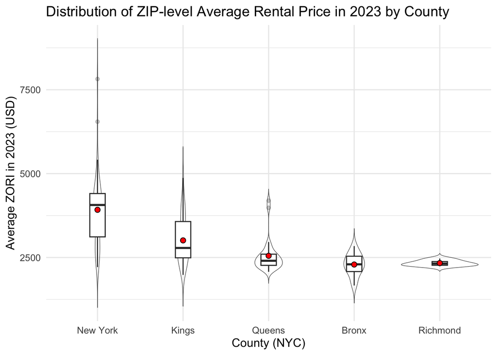

```r
#Q4) 2023 ZIP-level averages + distribution plot across counties
county_order <- c("New York","Kings","Queens","Bronx","Richmond")

zip_2023_avg <- zori_long %>%
  filter(year == 2023, !is.na(zori), !is.na(borough)) %>%
  group_by(borough, zip) %>%
  summarise(avg_2023 = mean(zori, na.rm = TRUE), .groups = "drop") %>%
  mutate(borough = factor(borough, levels = county_order))

# Reader-friendly distribution plot across boroughs
p_zip_dist_2023 <- ggplot(zip_2023_avg, aes(borough, avg_2023)) +
  geom_violin(trim = FALSE, alpha = 0.25, linewidth = 0.2) +
  geom_boxplot(width = 0.18, outlier.alpha = 0.25) +
  stat_summary(fun = "mean", geom = "point", shape = 21, size = 2.2, fill = "red")  +
  labs(
    title = "Distribution of ZIP-level Average Rental Price in 2023 by County",
    x = "County (NYC)",
    y = "Average ZORI in 2023 (USD)"
  ) +
  theme_minimal(base_size = 12) +
  theme(legend.position = "none")

p_zip_dist_2023
```

```r
# Comment:
# New York (Manhattan) and Kings (Brooklyn) have the highest medians and widest upper tails, indicating more expensive and variable ZIPs; Queens is intermediate; Bronx and Richmond (Staten Island) show lower medians and tighter spreads.
```

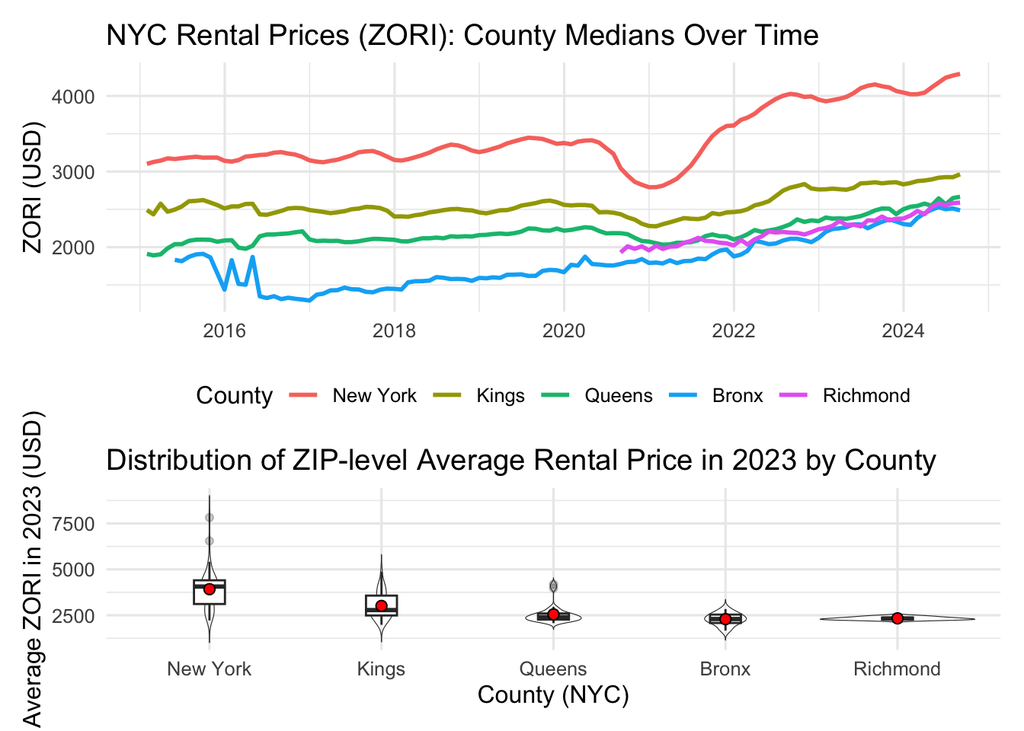

```r
#Q5: combine two plots
dir.create("problem 2 results", showWarnings = FALSE)
library(patchwork)

combined <- p1 /p_zip_dist_2023 + plot_layout(heights = c(2, 1.3))
combined
```

```r
ggsave("problem 2 results/combined_plots.png", combined, width = 10, height = 10, dpi = 300)
ggsave("problem 2 results/zori_county_median_over_time.png", p1, width = 10, height = 6, dpi = 300)
ggsave("problem 2 results/zori_2023_zip_distribution_by_county.png", p_zip_dist_2023, width = 9, height = 5, dpi = 300)

cat("Saved to problem 2 results/: combined_plots.png, zori_county_median_over_time.png, zori_2023_zip_distribution_by_county.png\n")
```

```
## Saved to problem 2 results/: combined_plots.png, zori_county_median_over_time.png, zori_2023_zip_distribution_by_county.png
```

## Problem 3

```r
library(tidyverse)
library(janitor)
library(lubridate)
library(hms)
```

```r
accel_path <- "/Users/caiyilin/Desktop/p8105_hw3_yc4804/problem_3_data/nhanes_accel.csv"
covar_path <- "/Users/caiyilin/Desktop/p8105_hw3_yc4804/problem_3_data/nhanes_covar.csv"

accel_raw <- readr::read_csv(accel_path, show_col_types = FALSE)
covar_raw <- readr::read_csv(
  "/Users/caiyilin/Desktop/p8105_hw3_yc4804/problem_3_data/nhanes_covar.csv",
  skip = 4,                 # <- use the 5th row as the header
  show_col_types = FALSE
)

# ---- Recode demographics with reasonable classes ----
covar <- covar_raw |>
  mutate(
    # sex: 1 = male, 2 = female (from your legend)
    sex = case_when(
      sex == 1 ~ "Male",
      sex == 2 ~ "Female",
      TRUE ~ NA_character_
    ),
    sex = factor(sex, levels = c("Female", "Male")),

    # age numeric integer
    age = as.integer(age),

    # bmi numeric
    BMI = as.numeric(BMI),

    # education: 1 < HS, 2 HS equivalent, 3 > HS  (ordered)
    education = case_when(
      education == 1 ~ "< High school",
      education == 2 ~ "High school equivalent",
      education == 3 ~ "More than high school",
      TRUE ~ NA_character_
    ),
    education = factor(education,
                       levels = c("< High school", "High school equivalent", "More than high school"),
                       ordered = TRUE)
  )

# ---- Exclude: age < 21, AND any missing demographic values ----
demo_cols <- c("sex","age","BMI","education")
covar_clean <- covar |>
  drop_na(all_of(demo_cols)) |>
  filter(age >= 21)

# ---- Tidy accelerometer to long: one row per person–minute ----
minute_cols <- names(accel_raw)[stringr::str_detect(names(accel_raw), "^min\\d+$")]

accel_long <- accel_raw |>
  select(SEQN, all_of(minute_cols)) |>
  pivot_longer(
    cols = all_of(minute_cols),
    names_to  = "minute_var",     # e.g., "min537"
    values_to = "MIMS"
  ) |>
  mutate(
    minute     = readr::parse_number(minute_var),   # 1..1440
    .after = SEQN
  ) |>
  select(-minute_var)

# ---- Merge (inner join = participants present in both) ----
nhanes_long <- accel_long |>
  inner_join(covar_clean, by = "SEQN") |>
  arrange(SEQN, minute)

view(nhanes_long)

# Objects you can use:
#   nhanes_long: tidy dataset with columns
#     seqn, minute, time_of_day, mims, sex, age, bmi, education
```

```r
library(dplyr)
library(ggplot2)
library(knitr)

## Counts table (reader-friendly)
sex_ed_counts <- nhanes_long %>%
  distinct(SEQN, sex, education) %>%     # one row per participant
  count(education, sex) %>%
  tidyr::pivot_wider(names_from = sex, values_from = n, values_fill = 0) %>%
  arrange(education)

kable(sex_ed_counts,
      caption = "Number of Men and Women by Education Category",
      align = "c")
```

Number of Men and Women by Education Category

| education | Female | Male |
| --- | --- | --- |
| < High school | 28 | 27 |
| High school equivalent | 23 | 35 |
| More than high school | 59 | 56 |

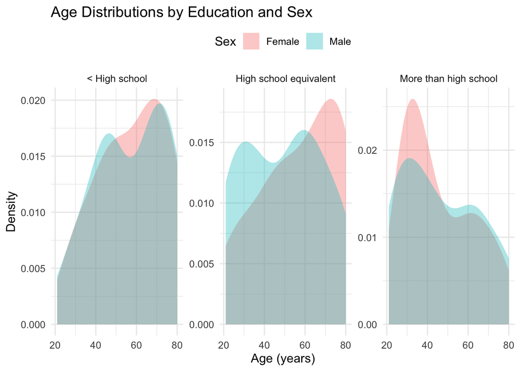

```r
## Age distributions (density) by sex within education
age_dist <- nhanes_long %>%
  distinct(SEQN, age, sex, education) %>%
  mutate(education = droplevels(education))

ggplot(age_dist, aes(x = age, fill = sex)) +
  geom_density(alpha = 0.35, adjust = 1.0, color = NA) +
  facet_wrap(~ education, nrow = 1, scales = "free_y") +
  scale_fill_discrete(name = "Sex") +
  labs(title = "Age Distributions by Education and Sex",
       x = "Age (years)", y = "Density") +
  theme_minimal(base_size = 12) +
  theme(legend.position = "top")
```

A quick read of the figure shows clear age shifts across education levels. In the < high school group, both men and women skew older, with most density in the late 60s–70s. The high school equivalent group is broader; men look slightly bimodal (30s and 60s), while women lean older (mid-50s to 70s). In more than high school, women skew younger with a prominent peak in the 30s, whereas men are more evenly spread into later adulthood. Despite these shifts, the sexes overlap substantially within each education category.